# Coronavirus Data Analysis

Marcelo Sanches

04/02/2020

This is a simple exploration of the time series data which was compiled by the Johns Hopkins University Center for Systems Science and Engineering (JHU CCSE) from various sources (see website for full description). The data can be downloaded manually at [Novel Coronavirus 2019 Cases.](https://data.humdata.org/dataset/novel-coronavirus-2019-ncov-cases)

## Contents

- Data Pre-Processing: brief description of pre-processing steps.
- Data Cleanup: brief summary of cleanup.
- Exploratory Data Analysis: main section with visualizations [IN PROGRESS…]
- Outcome Simulation: simulations of possible outcomes. [TO DO]
- Code Appendix: entire R code.

## Data Pre-Processing

The `preprocess` function creates a local folder and pulls three csv files, one for each stage in tracking the coronavirus spread (confirmed, fatal, and recovered cases), performs various pre-processing steps to create one narrow and long dataset, saving it in compressed RDS format. See code in the Code Appendix.

```r
# read in RDS file
dfm <- preprocess()

str(dfm)
```

```
## 'data.frame':    55480 obs. of  7 variables:
##  $ Province_State: chr  NA NA NA NA ...
##  $ Country_Region: chr  "Afghanistan" "Afghanistan" "Afghanistan" "Afghanistan" ...
##  $ Lat           : num  33 33 33 33 33 33 33 33 33 33 ...
##  $ Long          : num  65 65 65 65 65 65 65 65 65 65 ...
##  $ Date          : Date, format: "2020-04-03" "2020-04-02" ...
##  $ Value         : int  281 273 237 174 170 120 110 110 94 84 ...
##  $ Status        : Factor w/ 3 levels "Confirmed","Fatal",..: 1 1 1 1 1 1 1 1 1 1 ...
```

There are 55480 rows and 7 columns. There’s a ‘Status’ column for the different stages, so the number of rows is 3 times the number of rows for a single status (ex. “confirmed”). Each single-status dataset is as long as the number of days in the time series (for a given day the data is pulled) times the number of countries and sub-national provinces or states. This number varies per country, and also varies per day depending on how the dataset is built.

Back to Contents

## Data Cleanup

### Location Granularity

The data’s location variables have several issues. I will discard `Lat` and `Long` since I’m not doing any mapping. The variables `Country_Region` and `Province_State` are often loosely aggregated. This can be visualized in [Johns Hopkins’ dashboard](https://coronavirus.jhu.edu/map.html): the totals for fatalities are grouped by a mixture of countries and subnational geographic areas. The US is conspicuously missing as a country.

Since subnational data is sparse, I’ll focus on country-level data. After some data analysis, I noticed that the anomalies will repond to one simple aggregation and I recreated the dataset at this national level. Canada is a prime example of bad data: notice how it lacks subnational data on recovered cases, but also, I doubt there’s a province in Canada called ‘Recovered’:

| Country_Region | Province_State | Status |
| --- | --- | --- |
| Canada | Alberta | Confirmed |
| Canada | British Columbia | Confirmed |
| Canada | Diamond Princess | Confirmed |
| Canada | Grand Princess | Confirmed |
| Canada | Manitoba | Confirmed |
| Canada | New Brunswick | Confirmed |
| Canada | Newfoundland and Labrador | Confirmed |
| Canada | Northwest Territories | Confirmed |
| Canada | Nova Scotia | Confirmed |
| Canada | Ontario | Confirmed |
| Canada | Prince Edward Island | Confirmed |
| Canada | Quebec | Confirmed |
| Canada | Recovered | Confirmed |
| Canada | Saskatchewan | Confirmed |
| Canada | Yukon | Confirmed |
| Canada | Alberta | Fatal |
| Canada | British Columbia | Fatal |
| Canada | Diamond Princess | Fatal |
| Canada | Grand Princess | Fatal |
| Canada | Manitoba | Fatal |
| Canada | New Brunswick | Fatal |
| Canada | Newfoundland and Labrador | Fatal |
| Canada | Northwest Territories | Fatal |
| Canada | Nova Scotia | Fatal |
| Canada | Ontario | Fatal |
| Canada | Prince Edward Island | Fatal |
| Canada | Quebec | Fatal |
| Canada | Recovered | Fatal |
| Canada | Saskatchewan | Fatal |
| Canada | Yukon | Fatal |
| Canada | NA | Recovered |

The top and bottom rows for the final dataset:

|  | Country | Status | Date | Count |
| --- | --- | --- | --- | --- |
| 1 | Afghanistan | Confirmed | 2020-04-03 | 281 |
| 2 | Afghanistan | Confirmed | 2020-04-02 | 273 |
| 3 | Afghanistan | Confirmed | 2020-04-01 | 237 |
| 4 | Afghanistan | Confirmed | 2020-03-31 | 174 |
| 5 | Afghanistan | Confirmed | 2020-03-30 | 170 |
| 6 | Afghanistan | Confirmed | 2020-03-29 | 120 |
| 39634 | Zimbabwe | Recovered | 2020-01-27 | 0 |
| 39635 | Zimbabwe | Recovered | 2020-01-26 | 0 |
| 39636 | Zimbabwe | Recovered | 2020-01-25 | 0 |
| 39637 | Zimbabwe | Recovered | 2020-01-24 | 0 |
| 39638 | Zimbabwe | Recovered | 2020-01-23 | 0 |
| 39639 | Zimbabwe | Recovered | 2020-01-22 | 0 |

Back to Contents

## Exploratory Data Analysis

#### WORLD TOTALS

| Status | Total |
| --- | --- |
| Confirmed | 1095917 |
| Fatal | 58787 |
| Recovered | 225796 |

#### TOP TEN COUNTRIES PER STATUS

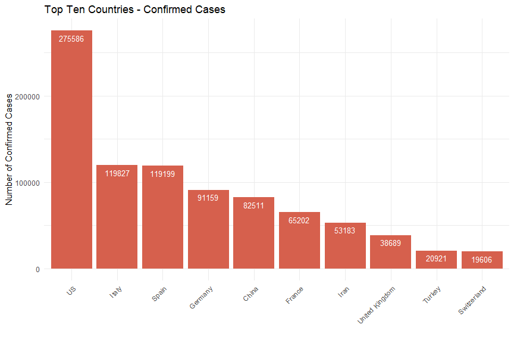

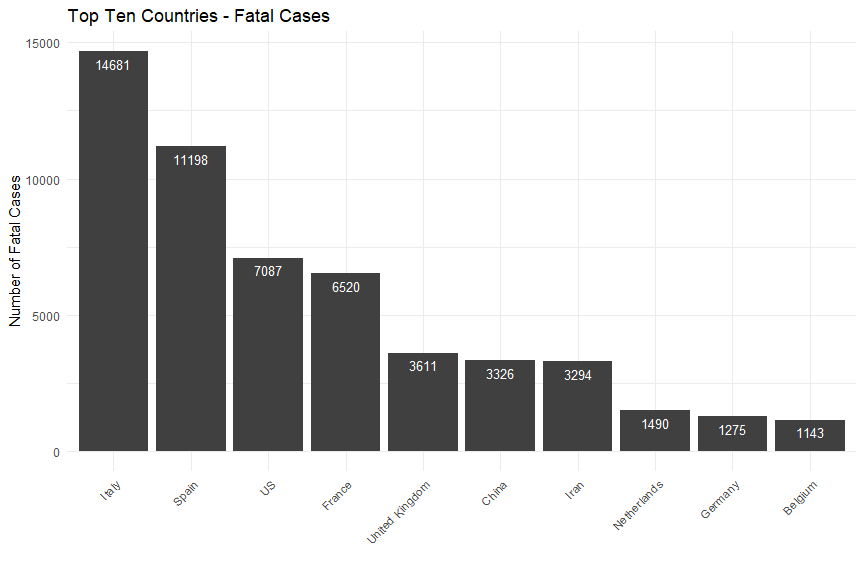

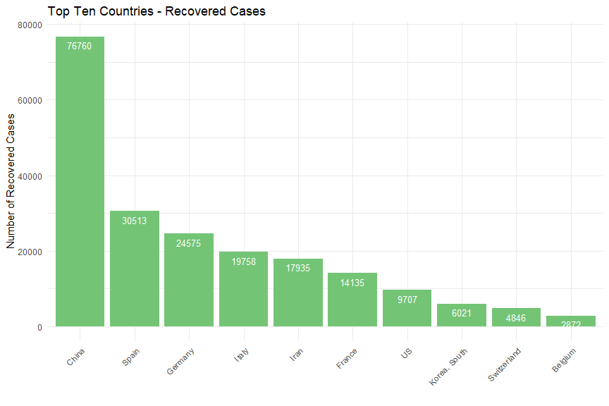

### Time Series Plots per Status and Location

[interactive chart not shown]

#### Per Capita Analysis

Raw counts only tell part of the story. Since the probability of, say, being diagnosed with COVID-19 is somewhat dependent on the percentage of people in a country that were diagnosed with the disease, the raw count divided by the population of a country would provide a better estimate of how one country compares to another.

For example, the number of confirmed cases in the US is much higher now than any other country, yet because there are roughly 322 million people in the US, it ranks lower than most smaller countries in percentage of confirmed cases.

**Top 25 Confirmed Cases by Percentage of Population**

| Country | Status | Date | Count | Population_thousands | Pct |
| --- | --- | --- | --- | --- | --- |
| Diamond Princess | Confirmed | 2020-04-03 | 712 | 4 | 17.8000000 |
| San Marino | Confirmed | 2020-04-03 | 245 | 33 | 0.7424242 |
| Holy See | Confirmed | 2020-04-03 | 7 | 1 | 0.7000000 |
| Andorra | Confirmed | 2020-04-03 | 439 | 77 | 0.5701299 |
| Luxembourg | Confirmed | 2020-04-03 | 2612 | 576 | 0.4534722 |
| MS Zaandam | Confirmed | 2020-04-03 | 9 | 2 | 0.4500000 |
| Iceland | Confirmed | 2020-04-03 | 1364 | 332 | 0.4108434 |
| Spain | Confirmed | 2020-04-03 | 119199 | 46348 | 0.2571826 |
| Switzerland | Confirmed | 2020-04-03 | 19606 | 8402 | 0.2333492 |
| Italy | Confirmed | 2020-04-03 | 119827 | 59430 | 0.2016271 |
| Liechtenstein | Confirmed | 2020-04-03 | 75 | 39 | 0.1923077 |
| Monaco | Confirmed | 2020-04-03 | 64 | 38 | 0.1684211 |
| Belgium | Confirmed | 2020-04-03 | 16770 | 11358 | 0.1476492 |
| Austria | Confirmed | 2020-04-03 | 11524 | 8712 | 0.1322773 |
| Germany | Confirmed | 2020-04-03 | 91159 | 81915 | 0.1112849 |
| Norway | Confirmed | 2020-04-03 | 5370 | 5255 | 0.1021884 |
| France | Confirmed | 2020-04-03 | 65202 | 64721 | 0.1007432 |
| Portugal | Confirmed | 2020-04-03 | 9886 | 10372 | 0.0953143 |
| Netherlands | Confirmed | 2020-04-03 | 15821 | 16987 | 0.0931359 |
| Israel | Confirmed | 2020-04-03 | 7428 | 8192 | 0.0906738 |
| Ireland | Confirmed | 2020-04-03 | 4273 | 4726 | 0.0904147 |
| US | Confirmed | 2020-04-03 | 275586 | 322180 | 0.0855379 |
| Estonia | Confirmed | 2020-04-03 | 961 | 1312 | 0.0732470 |
| Denmark | Confirmed | 2020-04-03 | 3946 | 5712 | 0.0690826 |
| Iran | Confirmed | 2020-04-03 | 53183 | 80277 | 0.0662494 |

Since the cruise ships Diamond Princess and MS Zaandam are not countries and dominate plots in a perhaps unrealistic comparison, I am removing them from from consideration in the plots below.

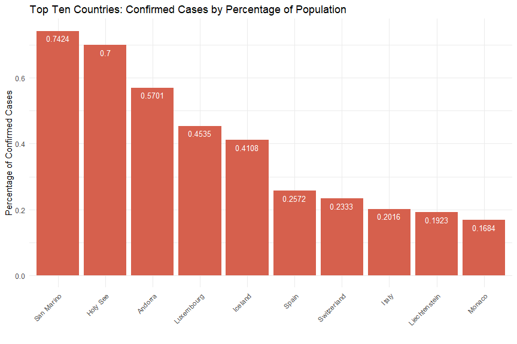

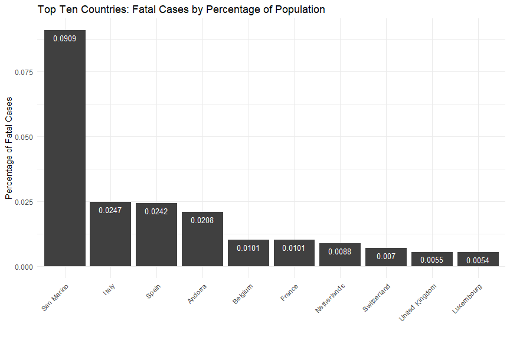

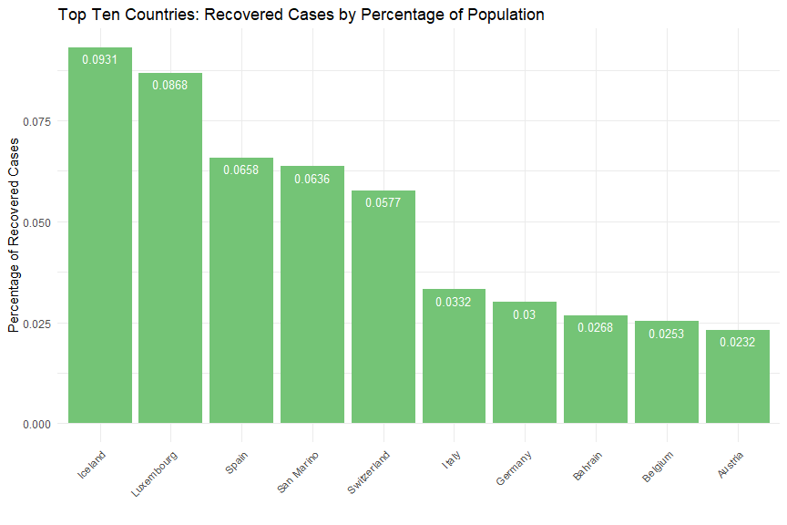

### Time Series by Percentage - Linear & Log

Following are time series plots of percentages in linear and (natural) log scales for the top six countries in each category.

[interactive chart not shown]

### Time Series Of New Cases

The most interesting plots would show how the disease is progressing. One way is to track how many new cases pop up every day. Since the daily number is a bit erratic, I first calculate the previous week’s daily average (mean) and select the top countries with highest mean daily number of new cases per status.

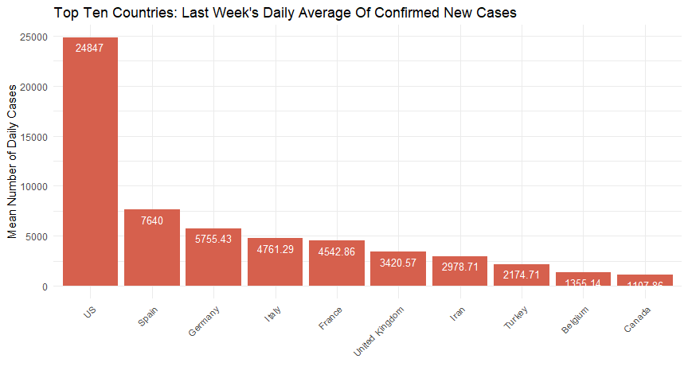

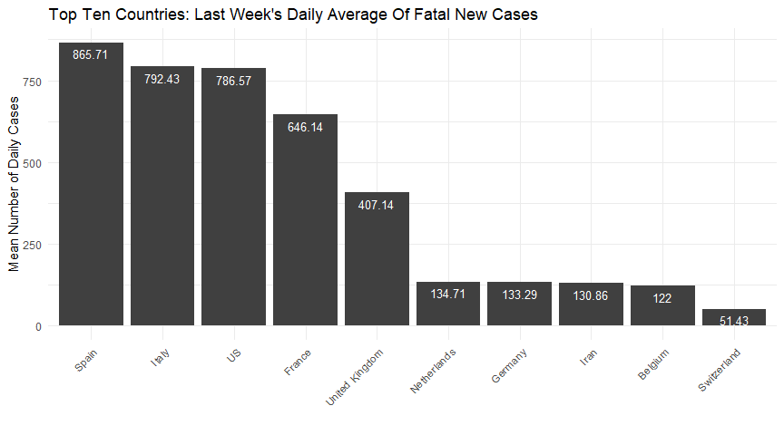

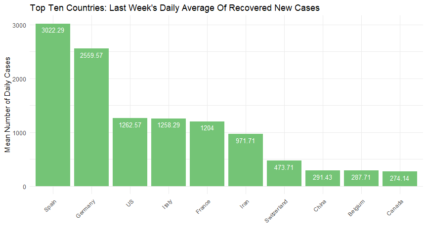

[interactive chart not shown]

[interactive chart not shown]

```
TO DO:

  Doubling rate - calculate how many days it takes to double a given status count, plot that.
  Plot proportion of New to Total Cases, Linear and Log scales.
  Plot against Time and with Time as interaction.
  Outcome Simulation section.
  Add more links throughough document.
```

## Outcome Simulation

Back to Contents

### Code Appendix

```r
## ----setup, include=FALSE------------------------------------------------
knitr::opts_chunk$set(echo = TRUE)

## ----include=FALSE-------------------------------------------------------
# setup
rm(list = ls())
options(scipen=999)

install_packages <- function(package){

  newpackage <- package[!(package %in% installed.packages()[, "Package"])]

    if (length(newpackage)) {
      suppressMessages(install.packages(newpackage, dependencies = TRUE))
    }
    sapply(package, require, character.only = TRUE)
}


# install packages
packages <- c("dygraphs", "tidyverse", "xts", "RColorBrewer","kableExtra")
suppressPackageStartupMessages(install_packages(packages))

## ----include=FALSE-------------------------------------------------------

# preprocessing function
preprocess <- function() {

    # create a folder for the data
    dir_name <- "COVID19_DATA"
    if (!file.exists(dir_name)) {
        dir.create(dir_name)
    }

    dir_path <- "COVID19_DATA/"

    # download today's file, save as RDS first time, read otherwise
    file_name <- paste0(dir_path, gsub("-", "", Sys.Date()), "_data.rds")

    if (!file.exists(file_name)) {

        # create URLs
        http_header <- paste0("https://data.humdata.org/hxlproxy/data/"
                              ,"download/time_series_covid19_")

        url_body <- paste0("_narrow.csv?dest=data_edit&filter01=explode&explode"
                    ,"-header-att01=date&explode-value-att01=value&filter02=ren"
                    ,"ame&rename-oldtag02=%23affected%2Bdate&rename-newtag02=%2"
                    ,"3date&rename-header02=Date&filter03=rename&rename-oldtag0"
                    ,"3=%23affected%2Bvalue&rename-newtag03=%23affected%2Binfec"
                    ,"ted%2Bvalue%2Bnum&rename-header03=Value&filter04=clean&cl"
                    ,"ean-date-tags04=%23date&filter05=sort&sort-tags05=%23date"
                    ,"&sort-reverse05=on&filter06=sort&sort-tags06=%23country%2"
                    ,"Bname%2C%23adm1%2Bname&tagger-match-all=on&tagger-default"
                    ,"-tag=%23affected%2Blabel&tagger-01-header=province%2Fstat"
                    ,"e&tagger-01-tag=%23adm1%2Bname&tagger-02-header=country%2"
                    ,"Fregion&tagger-02-tag=%23country%2Bname&tagger-03-header="
                    ,"lat&tagger-03-tag=%23geo%2Blat&tagger-04-header=long&tagg"
                    ,"er-04-tag=%23geo%2Blon&header-row=1&url=https%3A%2F%2Fraw"
                    ,".githubusercontent.com%2FCSSEGISandData%2FCOVID-19%2Fmast"
                    ,"er%2Fcsse_covid_19_data%2Fcsse_covid_19_time_series%2Ftim"
                    ,"e_series_covid19_")


        confirmed_URL  <- paste0(http_header, "confirmed_global"
                                 , url_body, "confirmed_global.csv")
        fatal_URL <- paste0(http_header, "deaths_global"
                            , url_body, "deaths_global.csv")
        recovered_URL  <- paste0(http_header, "recovered_global"
                                 , url_body, "recovered_global.csv")

        # download
        download.file(confirmed_URL
                      , destfile=paste0(dir_path, "confirmed.csv"))
        download.file(fatal_URL
                      , destfile=paste0(dir_path, "fatal.csv"))
        download.file(recovered_URL
                      , destfile=paste0(dir_path, "recovered.csv"))

        # load csvs
        load_csv <- function(filename) {
            filename <- read.csv(paste0(dir_path, filename, ".csv"), header=TRUE
                                 , fileEncoding="UTF-8-BOM"
                                 , stringsAsFactors=FALSE, na.strings="")[-1, ]
            filename
        }

        confirmed  <- load_csv("confirmed")
        fatal <- load_csv("fatal")
        recovered  <- load_csv("recovered")

        # prep data for long format

        # add column identifying the dataset
        add_col <- function(dfm, name) {
            dfm$Status <- rep(name, nrow(dfm))
            dfm
        }

        confirmed  <- add_col(confirmed, "Confirmed")
        fatal <- add_col(fatal, "Fatal")
        recovered  <- add_col(recovered, "Recovered")

        # join (union actually) into one dataset
        dfm <- rbind(confirmed, fatal, recovered, make.row.names=FALSE)

        # rename columns
        colnames(dfm) <- c("Province_State", "Country_Region"
                  , "Lat", "Long", "Date", "Value", "Status")

        # fix data types
        dfm$Value <- as.integer(dfm$Value)
        dfm$Lat <- as.numeric(dfm$Lat)
        dfm$Long <- as.numeric(dfm$Long)
        dfm$Date <- as.Date(dfm$Date)
        dfm$Status <- as.factor(dfm$Status)

        # save as RDS
        saveRDS(dfm, file = file_name)

    }

    dfm <- readRDS(file_name)

}


## ------------------------------------------------------------------------
# read in RDS file
dfm <- preprocess()

str(dfm)


nrow(dfm)
length(dfm)
## ----echo=FALSE----------------------------------------------------------
# Canada provinces example
kable(data.frame(dfm[dfm$Country_Region == "Canada", ]) %>%
           distinct(Country_Region, Province_State, Status)) %>%
      kable_styling(bootstrap_options = c("striped", "hover", "condensed")
                  , full_width = FALSE)

## ----include=FALSE-------------------------------------------------------
# country-level dataset
country_level_df <- data.frame(dfm %>%
                               select(Country_Region, Status, Date, Value) %>%
                               group_by(Country_Region, Status, Date) %>%
                               summarise('Value'=sum(Value))) %>%
                               arrange(Country_Region, Status, desc(Date))

colnames(country_level_df) <- c("Country", "Status", "Date", "Count")

Ncountries <- length(unique(country_level_df$Country))
Ndays <- length(unique(country_level_df$Date))

# check: is the number of rows equal to the number of countries
# times the number of days times 3 (statuses)?
nrow(country_level_df) == Ncountries * Ndays * 3
```

```r
## ----echo=FALSE----------------------------------------------------------
# top and bottom rows for final dataset
kable(rbind(head(country_level_df)
     ,tail(country_level_df))) %>%
      kable_styling(bootstrap_options = c("striped", "hover", "condensed")
                  , full_width = FALSE)

## ----echo=FALSE----------------------------------------------------------
# subset to current counts
current_data <- data.frame(country_level_df %>%
                    filter(Date == unique(country_level_df$Date)[1])) %>%
                    arrange(Status, desc(Count))

# subset to world totals
world_totals <- data.frame(current_data %>%
                    group_by(Status) %>%
                    summarise('Total'=sum(Count)))


kable(world_totals) %>%
      kable_styling(bootstrap_options = c("striped", "hover")
                    , full_width = FALSE)

## ----echo=FALSE----------------------------------------------------------
# subset to country totals
country_totals <- data.frame(current_data %>%
                        select(Country, Status, Count) %>%
                        group_by(Country, Status))

# subset to top counts
get_top10_counts <- function(dfm, coln) {

    dfm <- dfm[dfm$Status == coln, c(1,3)][1:10,]
    row.names(dfm) <- 1:10
    dfm
}

# separate by status
top10_confirmed     <- get_top10_counts(country_totals, "Confirmed")
top10_fatal <- get_top10_counts(country_totals, "Fatal")
top10_recovered     <- get_top10_counts(country_totals, "Recovered")

# plot top countries per status
gg_plot <- function(dfm, status, color) {

    ggplot(data=dfm, aes(x=reorder(Country, -Count), y=Count)) +
        geom_bar(stat="identity", fill=color) +
        ggtitle(paste0("Top Ten Countries - ", status, " Cases")) +
        xlab("") + ylab(paste0("Number of ", status, " Cases")) +
        geom_text(aes(label=Count), vjust=1.6, color="white", size=3.5) +
    theme_minimal() +
    theme(axis.text.x = element_text(angle = 45, hjust = 1))
}

## ----fig.height=6, fig.width=9, echo=FALSE-------------------------------
# top confirmed
gg_plot(top10_confirmed, "Confirmed", "#D6604D")

# top fatal
gg_plot(top10_fatal, "Fatal", "gray25")

# top recovered
gg_plot(top10_recovered, "Recovered", "#74C476")


## ----include=FALSE-------------------------------------------------------
# subset to top 6 counts
get_top6_counts <- function(dfm, coln) {

    dfm <- dfm[dfm$Status == coln, c(1,3)][1:6,]
    row.names(dfm) <- 1:6
    dfm
}

top6_confirmed  <- get_top6_counts(country_totals, "Confirmed")
top6_fatal  <- get_top6_counts(country_totals, "Fatal")
top6_recovered  <- get_top6_counts(country_totals, "Recovered")


## ----include=FALSE-------------------------------------------------------
# functions for plotting interactive time series

# arg values:
# dfm = the dataframe
# country = country name
# status_df = to be used as the vector of country names
#             which is passed instead of a single country
# status = Confirmed, Fatal, Recovered
# scale_ = Linear, Log
# type = Count, Pct

create_xts_series <- function(dfm, country, status, scale_, type) {

    dfm <- dfm[dfm$Country == country & dfm$Status == status, ]

    if (type == "Count") {

      series <- if (scale_ == "Linear") {
                xts(dfm$Count, order.by = dfm$Date)
            } else {
              xts(log(dfm$Count), order.by = dfm$Date)
            }

    } else if (type == "Pct") {

      series <- if (scale_ == "Linear") {
                xts(dfm$Pct, order.by = dfm$Date)
            } else {
              xts(log(dfm$Pct), order.by = dfm$Date)
            }
    } else {

      series <- if (scale_ == "Linear") {
                xts(dfm$NewCases, order.by = dfm$Date)
            } else {
              xts(log(dfm$NewCases), order.by = dfm$Date)
            }
    }
    series
}


create_seriesObject <- function(dfm, status_df, status, scale_, type) {

  seriesObject <- NULL
  for (i in 1:6) {

    seriesObject <- cbind(seriesObject
                          , create_xts_series(dfm
                                              , status_df$Country[i]
                                              , status
                                              , scale_
                                              , type)
                          )
  }

  names(seriesObject) <- status_df$Country[1:6]
  seriesObject
}

plot_interactive_df <- function(dfm, status_df, status, scale_, type) {

  seriesObject <- create_seriesObject(dfm
                                      , status_df
                                      , status
                                      , scale_
                                      , type)

  if (type == "Count") {

    ylab_txt <- if (scale_ == "Linear") {
                    "Number Of "
                } else {
                  "Log Count - "
                }
  } else if (type == "Pct") {

    ylab_txt <- if (scale_ == "Linear") {
                    "Percentage Of "
                } else {
                  "Log Percentage - "
                }
  } else {

    ylab_txt <- if (scale_ == "Linear") {
                    "Number Of New "
                } else {
                  "Log Count of New - "
                }
  }

  ylab_lab <- paste0(ylab_txt, status, " Cases")
  main_title <- paste0("Top Six Countries - ", status
                     , " Cases (", scale_, " Scale)")

  interactive_df <- dygraph(seriesObject, main = main_title) %>%
                    dyAxis("x", drawGrid = FALSE) %>%
                    dyAxis("y", label = ylab_lab) %>%
                    dyOptions(colors=brewer.pal(6, "Dark2")
                            , axisLineWidth = 1.5
                            , axisLineColor = "navy"
                            , gridLineColor = "lightblue") %>%
                    dyRangeSelector() %>%
                    dyLegend(width = 750)

  interactive_df
}

## ----fig.height=5, fig.width=9, echo=FALSE-------------------------------
# INTERACTIVE PLOTS - COUNT

# Confirmed
plot_interactive_df(country_level_df, top10_confirmed[1:6, ]
                    , "Confirmed", "Linear", "Count")
plot_interactive_df(country_level_df, top10_confirmed[1:6, ]
                    , "Confirmed", "Log", "Count")
```

```r
# Fatal
plot_interactive_df(country_level_df, top10_fatal[1:6,]
                    , "Fatal", "Linear", "Count")
plot_interactive_df(country_level_df, top10_fatal[1:6,]
                    , "Fatal", "Log", "Count")

# Recovered
plot_interactive_df(country_level_df, top10_recovered[1:6,]
                    , "Recovered", "Linear", "Count")
plot_interactive_df(country_level_df, top10_recovered[1:6,]
                    , "Recovered", "Log", "Count")

## ----include=FALSE-------------------------------------------------------
# Per Capita Analysis

# data enrichment and wranglingt

# read in prepared dataset of countries and populations
country_population <- read.csv("COVID19_DATA/country_population.csv")

# test for new countries in data
current_countries <- unique(country_level_df$Country)
current_countries[!current_countries %in% country_population$Country]

# merge datasets
percap <- merge(country_level_df, country_population, by="Country")

# create percentage col
percap$Pct <- (percap$Count/(percap$Population_thousands*1000))*100

# reorder by Country, Status, and Date descending
percap <- data.frame(percap %>%
                     arrange(Country, Status, desc(Date)))

# avoid NaNs in Log plots
percap$Pct[percap$Pct == 0] <- 0.0001

## ----echo=FALSE----------------------------------------------------------
# subset to current counts
current_data <- data.frame(percap %>%
                    filter(Date == unique(percap$Date)[1])) %>%
                    arrange(Status, desc(Pct))

kable(current_data[1:25, ]) %>%
  kable_styling(bootstrap_options = c("striped", "hover", "condensed")
                , full_width = FALSE)

## ----include=FALSE-------------------------------------------------------
# discard cruise ships from countries
cruise_ships <- c("Diamond Princess", "MS Zaandam")
current_data <- current_data[!current_data$Country %in% cruise_ships, ]

# subset to top ten percentages
get_top10_pcts <- function(dfm, coln) {

    dfm <- dfm[dfm$Status == coln, c(1,6)][1:10,]
    row.names(dfm) <- 1:10
    dfm$Pct <- round(dfm$Pct, 4)
    dfm
}

# separate by status
top10_confirmed     <- get_top10_pcts(current_data, "Confirmed")
top10_fatal <- get_top10_pcts(current_data, "Fatal")
top10_recovered     <- get_top10_pcts(current_data, "Recovered")

# plot top countries per status
gg_plot <- function(dfm, status, color) {

    ggplot(data=dfm, aes(x=reorder(Country, -Pct), y=Pct)) +
        geom_bar(stat="identity", fill=color) +
        ggtitle(paste0("Top Ten Countries: ", status
                       , " Cases by Percentage of Population")) +
        xlab("") + ylab(paste0("Percentage of ", status, " Cases")) +
        geom_text(aes(label=Pct), vjust=1.6, color="white", size=3.5) +
    theme_minimal() +
    theme(axis.text.x = element_text(angle = 45, hjust = 1))
}

## ----echo=FALSE, fig.height=6, fig.width=9-------------------------------
# top confirmed
gg_plot(top10_confirmed, "Confirmed", "#D6604D")

# top fatal
gg_plot(top10_fatal, "Fatal", "gray25")

# top recovered
gg_plot(top10_recovered, "Recovered", "#74C476")

## ----fig.height=5, fig.width=9, echo=FALSE-------------------------------
# Confirmed Cases
plot_interactive_df(percap, top10_confirmed[1:6, ]
                    , "Confirmed", "Linear", "Pct")
plot_interactive_df(percap, top10_confirmed[1:6, ]
                    , "Confirmed", "Log", "Pct")

# Fatal Cases
plot_interactive_df(percap, top10_fatal
                    , "Fatal", "Linear", "Pct")
plot_interactive_df(percap, top10_fatal
                    , "Fatal", "Log", "Pct")

# Recovered Cases
plot_interactive_df(percap, top10_recovered
                    , "Recovered", "Linear", "Pct")
plot_interactive_df(percap, top10_recovered
                    , "Recovered", "Log", "Pct")

## ----include=FALSE-------------------------------------------------------
# Calculate new cases
percap$NewCases <- NULL

for (i in  seq.int(from=1, to=(nrow(percap)-1), by=Ndays)) {

    for (j in i:(i+Ndays-1)) {
        percap$NewCases[j] <- percap$Count[j] - percap$Count[j+1]
    }

    if (i > 1) {
        percap$NewCases[i-1] <- 0
    }
}

percap$NewCases[nrow(percap)] <- 0
percap$NewCases <- as.integer(percap$NewCases)


# get last weeks data only
lastweek_vec <- percap$Date[1:7]
lastweek <- percap[percap$Date %in% lastweek_vec, ]

# calculate grouped means
lastweek <- data.frame(lastweek %>%
                       group_by(Country, Status) %>%
                       summarise(MeanNewCases=round(mean(NewCases),2)))

# status dfs reordered by mean new cases
confirmed <- lastweek[lastweek$Status == "Confirmed", ] %>%
             arrange(desc(MeanNewCases))
fatal <- lastweek[lastweek$Status == "Fatal", ] %>%
             arrange(desc(MeanNewCases))
recovered <- lastweek[lastweek$Status == "Recovered", ] %>%
             arrange(desc(MeanNewCases))


gg_plot <- function(dfm, status, color) {

    ggplot(data=dfm, aes(x=reorder(Country, -MeanNewCases), y=MeanNewCases)) +
        geom_bar(stat="identity", fill=color) +
        ggtitle(paste0("Top Ten Countries: Last Week's Daily Average Of ", status
                       , " New Cases")) +
        xlab("") + ylab("Mean Number of Daily Cases") +
        geom_text(aes(label=MeanNewCases), vjust=1.6, color="white", size=3.5) +
    theme_minimal() +
    theme(axis.text.x = element_text(angle = 45, hjust = 1))
}

## ----fig.height=5, fig.width=9, echo=FALSE-------------------------------
# Bar Plots - New Cases

# top confirmed
gg_plot(confirmed[1:10,], "Confirmed", "#D6604D")

# top fatal
gg_plot(fatal[1:10,], "Fatal", "gray25")

# top recovered
gg_plot(recovered[1:10,], "Recovered", "#74C476")

# Time Series - New Cases

# Confirmed Cases
plot_interactive_df(percap, confirmed[1:6,], "Confirmed", "Linear", "NewCases")
plot_interactive_df(percap, confirmed[1:6,], "Confirmed", "Log", "NewCases")

# Fatal Cases
plot_interactive_df(percap, fatal[1:6,], "Fatal", "Linear", "NewCases")
plot_interactive_df(percap, fatal[1:6,], "Fatal", "Log", "NewCases")
```

```r
# Recovered Cases
plot_interactive_df(percap, recovered[1:6,], "Recovered", "Linear", "NewCases")
plot_interactive_df(percap, recovered[1:6,], "Recovered", "Log", "NewCases")
```

```r
# uncomment to run, creates Rcode file with R code, set documentation = 1 to avoid text commentary
#library(knitr)
#options(knitr.purl.inline = TRUE)
#purl("COVID19_DATA_ANALYSIS.Rmd", output = "Rcode.R", documentation = 2)
```